# Final Coursework

## Deep learning workflow steps:

### Step 1: Define the problem

I am using the MNIST dataset, which contains a set of images of handwritten digits.

I am trying to solve the problem of correctly categorizing the digit in each image into their correct category. So this will be a single-label, multiclass classification problem.

The input samples will be the images, and the output will be a set of probabilities, determining which number the image most likely contains.

This dataset contains 70 000 samples (60 000 training and 10 000 test), so data isn't a limiting factor.

### Step 3: Choosing evaluation protocol

As a evaluation protocol, I will test the success of k-fold validation, but will maintain a hold-out validation set.

### Step 4: Preparing the data

The data has to be reshaped to a form that is acceptable to the network. The network will expect samples as vectors (1D arrays) of floating point values. The pixel map has to be straightened into a line of values.

```python
from tensorflow.keras.datasets import mnist
(train_images, train_labels), (test_images, test_labels) = mnist.load_data()
```

```python
print('tensor shape: ')
print('\ttraining images: ', train_images.shape)
print('\ttraining labels: ', train_labels.shape)
print('\ttest images: ', test_images.shape)
print('\ttest labels: ', test_labels.shape)
```

```
tensor shape:
	training images:  (60000, 28, 28)
	training labels:  (60000,)
	test images:  (10000, 28, 28)
	test labels:  (10000,)
```

```
samples:
```

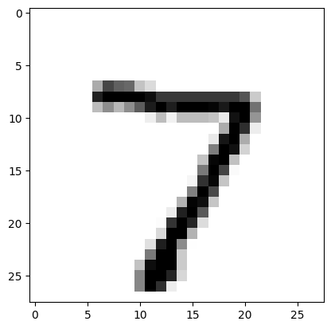

```
label: 7
```

```python
import matplotlib.pyplot as plt
xmpl_image = test_images[0]
xmpl_label = test_labels[0]
print('samples:')
plt.imshow(xmpl_image, cmap=plt.cm.binary)
plt.show()
print('label:', xmpl_label)
```

```python
# Reshape flattens 28 x 28 array to a vector of 783 elements
train_images = train_images.reshape((60000, 28*28))
test_images = test_images.reshape((10000, 28*28))

# Cast as floats and rescale to [0,1]
train_images = train_images.astype('float32') / 255
test_images = test_images.astype('float32') / 255
```

```python
print('tensor shape: ')
print('\ttraining images: ', train_images.shape)
print('\ttraining labels: ', train_labels.shape)
print('\ttest images: ', test_images.shape)
print('\ttest labels: ', test_labels.shape)
```

```
tensor shape:
	training images:  (60000, 784)
	training labels:  (60000,)
	test images:  (10000, 784)
	test labels:  (10000,)
```

```python
print(test_labels[0])
```

```
7
```

```python
# Encode with the to_categorical function
from tensorflow.keras.utils import to_categorical
orig_label = test_labels[0]
train_labels = to_categorical(train_labels)
test_labels = to_categorical(test_labels)



# Check encoding
print('\'', orig_label, '\'', 'as one-hot vector:\t', test_labels[0], sep='')
```

```
'7'as one-hot vector:	[0. 0. 0. 0. 0. 0. 0. 1. 0. 0.]
```

### Step 5: Developing a model that does better than a baseline

Here I wish to achieve statistical power by developing a small model that is capable of performing better than a random classifier.

This is a multiclass classification problem with 10 distinct classes, so I assume the baseline performance will be an accuracy of 0.1, since there is a 10% likelihood of each sample being classified correctly with a random classifier.

I will use categorical crossentropy as the loss function as it is most suitable for single-label multi-class classification tasks.

```python
from tensorflow.keras import models,layers
network1 = models.Sequential()
network1.add(layers.Dense(2, activation='relu', input_shape=(28*28,)))
network1.add(layers.Dense(10, activation='softmax'))

network1.compile(optimizer='rmsprop',
                loss='categorical_crossentropy',
                metrics=['accuracy'])
```

```python
# Fit the training data to the model
network1.fit(train_images, train_labels, epochs=1, batch_size=128)
```

```
<keras.callbacks.History at 0x1bf4ccddc40>
```

```python
# Evaluate on unseen test data
test_loss, test_acc = network1.evaluate(test_images, test_labels)
```

### Step 6: Scaling up the model

Now I will scale up the model capacity drastically, using 4 layers, 3 of which will have 1024 hidden units.

```python
network2 = models.Sequential()
network2.add(layers.Dense(1024, activation='relu', input_shape=(28*28,)))
network2.add(layers.Dense(1024, activation='relu'))
network2.add(layers.Dense(1024, activation='relu'))
network2.add(layers.Dense(10, activation='softmax'))

network2.compile(optimizer='rmsprop',
                loss='categorical_crossentropy',
                metrics=['accuracy'])
```

```python
network2.fit(train_images, train_labels, epochs=10, batch_size=256)
```

```
<keras.callbacks.History at 0x1bf5e739640>
```

```python
test_loss, test_acc = network2.evaluate(test_images, test_labels)
```

```python
network21 = models.Sequential()
network21.add(layers.Dense(300, activation='relu', input_shape=(28*28,)))
network21.add(layers.Dense(300, activation='relu'))
network21.add(layers.Dense(300, activation='relu'))
network21.add(layers.Dense(10, activation='softmax'))

network21.compile(optimizer='rmsprop',
                loss='categorical_crossentropy',
                metrics=['accuracy'])
```

```python
network21.fit(train_images, train_labels, epochs=10, batch_size=256)
```

```
<keras.callbacks.History at 0x1bf8d1bb6d0>
```

```python
test_loss, test_acc = network21.evaluate(test_images, test_labels)
```

### Step 7: Regularizing the model and tuning hyperparameters

I will implement weight regularization to try to reduce overfitting, and then compare the validation loss between the regularized and normal models.

To do this, I will use K-fold validation.

```python
# Getting the index to split the training set at a fifth
val_split = int(len(train_images)/5)

# Print the indexed values.
print("Total training samples: ", len(train_images))
print("Size of holdout set: ", val_split)

# Split the training set into training and validation sets
x_val = train_images[:val_split]
partial_train_images = train_images[val_split:]
y_val = train_labels[:val_split]
partial_train_labels = train_labels[val_split:]
```

```
Total training samples:  60000
Size of holdout set:  12000
```

```python
validationModel = models.Sequential()
validationModel.add(layers.Dense(300, activation='relu', input_shape=(28*28,)))
validationModel.add(layers.Dense(300, activation='relu'))
validationModel.add(layers.Dense(300, activation='relu'))
validationModel.add(layers.Dense(10, activation='softmax'))

validationModel.compile(optimizer='rmsprop',
                        loss='categorical_crossentropy',
                        metrics=['accuracy'])

validationHistory = validationModel.fit(partial_train_images,
                    partial_train_labels,
                    epochs=50,
                    batch_size=256,
                    validation_data=(x_val, y_val))
```

```python
test_loss, test_acc = validationModel.evaluate(test_images, test_labels)
```

Below I define a function plots a training metric against a validation metric:

```python
import matplotlib.pyplot as plt

def plot_epochs(x,
               y_A, style_A, label_A,
               y_B, style_B, label_B,
               title, x_label, y_label):
    plt.clf()
    plt.plot(x, y_A, style_A, label = label_A)
    plt.plot(x, y_B, style_B, label = label_B)
    plt.title(title)
    plt.xlabel(x_label)
    plt.ylabel(y_label)
    plt.legend()
    plt.show()
```

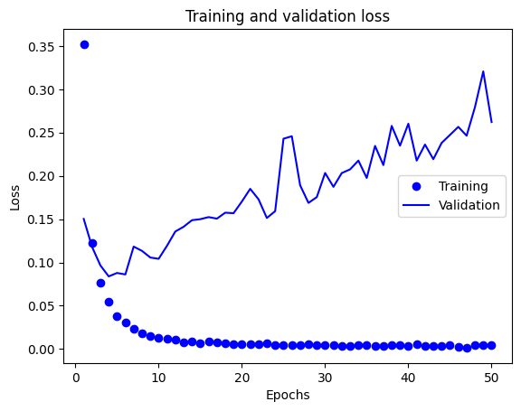

```python
# Using the function defined above to compare evaluation metrics
# on training set and validation set
loss = validationHistory.history['loss']
val_loss = validationHistory.history['val_loss']
acc = validationHistory.history['accuracy']
val_acc = validationHistory.history['val_accuracy']

plot_epochs(range(1, len(loss) + 1),
           loss, 'bo', 'Training',
            val_loss, 'b', 'Validation',
           'Training and validation loss',
           'Epochs',
           'Loss')
```

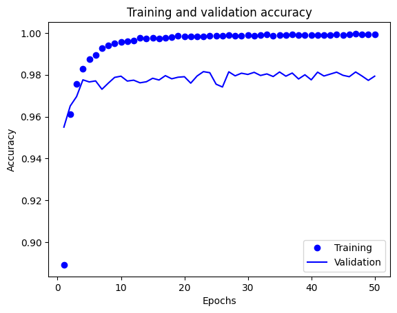

```python
plot_epochs(range(1, len(loss)+1),
            acc, 'bo', 'Training',
            val_acc, 'b', 'Validation',
            'Training and validation accuracy',
            'Epochs',
            'Accuracy')
```

I see that the validation set performance has significantly higher loss than the training set, as well as a lower accuracy.

To improve this performance, I will add kernel regularizers (L2(0.0000001)) to each layer.

```python
from tensorflow.keras import regularizers

RegularizedNetwork = models.Sequential()
RegularizedNetwork.add(layers.Dense(300,
                                    kernel_regularizer = regularizers.L2(0.0000001),
                                    activation='relu',
                                    input_shape=(28*28,)))
RegularizedNetwork.add(layers.Dense(300,
                                    kernel_regularizer = regularizers.L2(0.0000001),
                                    activation='relu'))
RegularizedNetwork.add(layers.Dense(300,
                                    kernel_regularizer = regularizers.L2(0.0000001),
                                    activation='relu'))
RegularizedNetwork.add(layers.Dense(10, activation='softmax'))

RegularizedNetwork.compile(optimizer='rmsprop',
                loss='categorical_crossentropy',
                metrics=['accuracy'])

ReguHistory = RegularizedNetwork.fit(partial_train_images,
                    partial_train_labels,
                    epochs=50,
                    batch_size=256,
                    validation_data=(x_val, y_val))
```

```python
test_loss, test_acc = RegularizedNetwork.evaluate(test_images, test_labels)
```

Below I define a function to compare the validation loss and accuracy of two models. I will use it to compare the Regularize and non-regularized models.

```python
def plot_loss_comparison(loss_a, label_a, loss_b, label_b, y_label):
    epochs = range(1, len(loss_a) + 1)

    plt.plot(epochs, loss_a, 'g+', label=label_a)
    plt.plot(epochs, loss_b, 'bo', label=label_b)
    plt.xlabel('Epochs')
    plt.ylabel(y_label)
    plt.legend()
    plt.show()
```

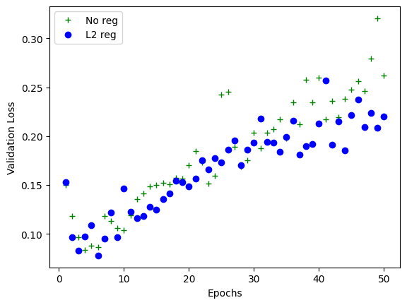

```python
plot_loss_comparison(validationHistory.history['val_loss'], 'No reg',
                   ReguHistory.history['val_loss'], 'L2 reg', 'Validation Loss')
```

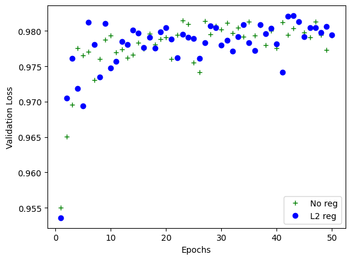

```python
plot_loss_comparison(validationHistory.history['val_accuracy'], 'No reg',
                   ReguHistory.history['val_accuracy'], 'L2 reg', 'Validation Loss')
```

Now I will add a dropout layer to lower the overfitting of the model. I will use a dropout rate of 0.25 This method neutralizes some of the samples, forcing the model to train harder on the data it gets.

```python
dropNetwork = models.Sequential()
dropNetwork.add(layers.Dense(300,
                             kernel_regularizer = regularizers.L2(0.0000001),
                             activation='relu', input_shape=(28*28,)))
dropNetwork.add(layers.Dropout(0.25))
dropNetwork.add(layers.Dense(300,
                             kernel_regularizer = regularizers.L2(0.0000001),
                             activation='relu'))
dropNetwork.add(layers.Dropout(0.25))
dropNetwork.add(layers.Dense(300,
                             kernel_regularizer = regularizers.L2(0.0000001),
                             activation='relu'))
dropNetwork.add(layers.Dropout(0.25))
dropNetwork.add(layers.Dense(10, activation='softmax'))

dropNetwork.compile(optimizer='rmsprop',
                loss='categorical_crossentropy',
                metrics=['accuracy'])

dropHistory = dropNetwork.fit(partial_train_images,
                    partial_train_labels,
                    epochs=50,
                    batch_size=256,
                    validation_data=(x_val, y_val))
```

```python
test_loss, test_acc = dropNetwork.evaluate(test_images, test_labels)
```

[figure not shown]

```python
plot_loss_comparison(validationHistory.history['val_loss'], 'No drop',
                   dropHistory.history['val_loss'], '0.5 Drop out', 'Validation Loss')
```

[figure not shown]

```python
plot_loss_comparison(validationHistory.history['val_accuracy'], 'No drop',
                   dropHistory.history['val_accuracy'], '0.5 Drop out', 'Validation Loss')
```

```python
import numpy as np
val_loss = dropHistory.history['val_loss']
lowest_loss = np.argmin(val_loss)
print(lowest_loss, ' epochs')
```

```
7  epochs
```

The dropout of 0.25 lowers the loss of the model within 10 epochs, and when it starts overfitting, it is at a slower and less volatile rate. It also has a positive effect of the accuracy, increasing the maximum and reducing fluctuations.

The accuracy and loss results vary each time I fit the same model, so to gain a better idea of the performance I'm getting, I will use K-fold validation and calculate the mean of the accuracies that I get.

```python
lowest_loss = 12
```

```python
import numpy as np

# K-Fold validation
# Number of folds
K=5
# Index for validation data
num_val_samples = len(train_images) // K
# Use lowest-loss epoch
num_epochs = lowest_loss
all_acc = []
all_loss = []

for i in range(K):
    print('processing fold: ', i)
    # create set of validation image data
    val_data = train_images[i * num_val_samples: (i+1) * num_val_samples]
    # create set of validation label data
    val_targets = train_labels[i * num_val_samples: (i+1) * num_val_samples]
    # concatenate the remaining partitions
    partial_train_data = np.concatenate([train_images[:i * num_val_samples],
                                         train_images[(i + 1) * num_val_samples:]],
                                       axis=0)
    partial_train_targets = np.concatenate([train_labels[:i * num_val_samples],
                                         train_labels[(i + 1) * num_val_samples:]],
                                       axis=0)

    # train and evaluate a fresh model
    k_network = models.Sequential()
    k_network.add(layers.Dense(300,
                               kernel_regularizer = regularizers.L2(0.0000001),
                               activation='relu', input_shape=(28*28,)))
    k_network.add(layers.Dropout(0.25))
    k_network.add(layers.Dense(300,
                               kernel_regularizer = regularizers.L2(0.0000001),
                               activation='relu'))
    k_network.add(layers.Dropout(0.25))
    k_network.add(layers.Dense(300,
                               kernel_regularizer = regularizers.L2(0.0000001),
                               activation='relu'))
    k_network.add(layers.Dropout(0.25))
    k_network.add(layers.Dense(10, activation='softmax'))

    k_network.compile(optimizer='rmsprop',
                    loss='categorical_crossentropy',
                    metrics=['accuracy'])
    # Train model
    k_network.fit(partial_train_data,
                  partial_train_targets,
                  epochs=num_epochs,
                  batch_size=256,
                  verbose=0)

    # Evaluate model
    test_loss, test_acc = k_network.evaluate(val_data, val_targets, verbose=0)
    all_acc.append(test_acc)
    all_loss.append(test_loss)

print('Fold accuracies: ', all_acc)
print('Mean accuracy: ', np.mean(all_acc))
print('Fold losses: ', all_loss)
print('Mean loss: ', np.mean(all_loss))
```

```
processing fold:  0
processing fold:  1
processing fold:  2
processing fold:  3
processing fold:  4
Fold accuracies:  [0.9808333516120911, 0.9778333306312561, 0.9783333539962769, 0.9761666655540466, 0.9794999957084656]
Mean accuracy:  0.9785333395004272
Fold losses:  [0.08351714164018631, 0.10177469998598099, 0.09974227845668793, 0.11103074997663498, 0.09656067192554474]
Mean loss:  0.09852510839700698
```

# Conclusion

In this project, I used the MNIST digit dataset to train a model for classifying images of digits.

The steps I took were as follows:

1. Created a small model to beat the baseline
2. Increased the model size to overfit
3. Slightly reduced model size, while still overfitting
4. Use a validation set to compare performance of loss and accuracy
5. Added kernel regularization and dropout layers to reduce overfitting
6. Finalized with K-fold validation to obtain an average of the losses and accuracies

The K-fold validation returned an average accuracy of 97.8% and a loss of 9.8%.

Although these is still overfitting in the model, since the training accuracy is higher than the testing accuracy, the techniques I've implemented to improve the models performance (dropout and regularization) improved the reliability of the model.